```python
%matplotlib inline
from matplotlib import pyplot as plt
import seaborn as sns
sns.set_style("white")
import sympy as sp
from mpl_toolkits.mplot3d import Axes3D
from matplotlib import cm
import numpy as np
sp.init_printing()
```

# Exercise 1

## 1.1 Compute and sketch the solutions

We rewrite the solution of dynamical linear systems given in the lecture:

$\begin{aligned} \mathbf{x}(t) &= e^{t\mathbf{A}}\mathbf{x}_0\\ &=e^{Pt\Lambda P^{-1}}\mathbf{x}_0\\ &=Pe^{t \operatorname{diag}(\lambda_1, \ldots, \lambda_n)}P^{-1}\mathbf{x}_0\\ &=P\left(\sum_{n=0}^\infty \frac{\operatorname{diag}(t^n \lambda_1^n, \ldots t^n \lambda^n)}{n!}\right)P^{-1}\mathbf{x}_0\\ &=P\operatorname{diag}\left(\sum_{n=0}^\infty \frac{t^n \lambda_1^n}{n!}, \ldots \sum_{n=0}^\infty \frac{t^n \lambda_m^n}{n!}\right)P^{-1}\mathbf{x}_0\\ &=P\operatorname{diag}\left(e^{t\lambda_1}, \ldots e^{t \lambda_m}\right)P^{-1}\mathbf{x}_0\\ \end{aligned}$

Now we can calculate $e^{t\mathbf{A}} = P\operatorname{diag}\left(e^{t\lambda_1}, \ldots e^{t \lambda_m}\right)P^{-1}$:

```python
A = sp.Matrix([[-0.5, -0.5, 0.], [-0.5, -0.5, 0.],[0.,0.,2.]])
P, L = A.diagonalize()
t = sp.Symbol('t')
etA = P.multiply((t*L).applyfunc(sp.exp)-sp.ones(3)+sp.eye(3)).multiply(P.inv())
etA
```

$$\left[\begin{matrix}0.5 + 0.5 e^{- 1.0 t} & -0.5 + 0.5 e^{- 1.0 t} & 0\\-0.5 + 0.5 e^{- 1.0 t} & 0.5 + 0.5 e^{- 1.0 t} & 0\\0 & 0 & 1.0 e^{2.0 t}\end{matrix}\right]$$

then we calculate the solution $\mathbf{x}(t)$:

```python
x0, x1, x2 = sp.Symbol("x0"), sp.Symbol("x1"), sp.Symbol("x2")
x = sp.Matrix([x0, x1, x2])
xt = etA.multiply(x)
xt
```

$$\left[\begin{matrix}x_{0} \left(0.5 + 0.5 e^{- 1.0 t}\right) + x_{1} \left(-0.5 + 0.5 e^{- 1.0 t}\right)\\x_{0} \left(-0.5 + 0.5 e^{- 1.0 t}\right) + x_{1} \left(0.5 + 0.5 e^{- 1.0 t}\right)\\1.0 x_{2} e^{2.0 t}\end{matrix}\right]$$

```python
# function to evaluate and plot x(t, x_0)
def x_tx0(tv, x0v):
    r = xt.evalf(subs={x0: x0v[0],
                       x1: x0v[1],
                       x2: x0v[2],
                       t: tv})
    return(np.array(r).astype(np.float64))
def plot(x0v, T=100, j=0):
    rs = []
    for i in range(T):
        rs.append(x_tx0(i, x0v))
    r = np.array(rs).squeeze()
    f= plt.figure(figsize=(10,5))
    ax=f.add_subplot(1,1,1)
    ax.plot(r[:,0], label=r'$x_1$')
    ax.plot(r[:,1], label=r'$x_2$')
    ax.plot(r[:,2], label=r'$x_3$')
    ax.set_xlabel("t")
    ax.set_ylabel("x(t)")
    ax.set_title(r"$x_{0,"+str(j)+"}$")
    sns.despine(offset=10, trim=True)
    plt.legend()
```

Plotting the solution for $\mathbf{x}_{0,1}=\left[\begin{array}{c}1\\1\\0\end{array}\right]$

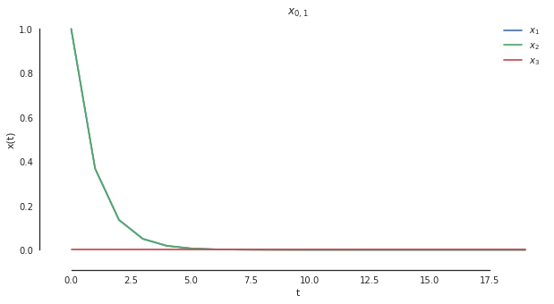

```python
plot(np.array([1., 1., 0.]), T=20, j=1)
```

Plotting the solution for $\mathbf{x}_{0,2}=\left[\begin{array}{c}1\\0\\0\end{array}\right]$

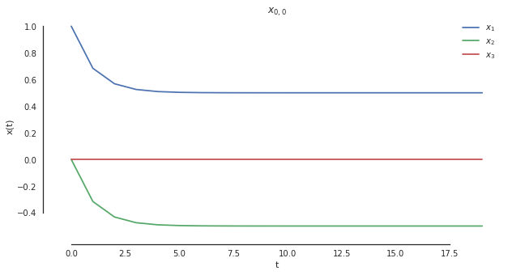

```python
plot(np.array([1., 0., 0.]), T=20)
```

Plotting the solution for $\mathbf{x}_{0,3}=\left[\begin{array}{c}0\\1\\0\end{array}\right]$

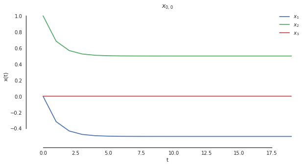

```python
plot(np.array([0., 1., 0.]), T=20)
```

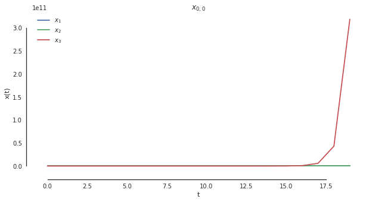

```python
plot(np.array([0., 0., 10e-6]), T=20)
```

## 1.2 Compute the eigenvectors and the eigenvalues of $\mathbf{A}$

```python
A = sp.Matrix([[-0.5, -0.5, 0.], [-0.5, -0.5, 0.],[0.,0.,2.]])
P, L = A.diagonalize()
```

The (not normalized) eigen vectors.

```python
P
```

$$\left[\begin{matrix}1.0 & -1.0 & 0\\1.0 & 1.0 & 0\\0 & 0 & 1.0\end{matrix}\right]$$

The eigen values

```python
L[0,0], L[1,1], L[2,2]
```

$$\left ( -1.0, \quad 0, \quad 2.0\right )$$

The first initial condition $\mathbf{x}_{0,1}=\left[\begin{array}{c}1\\1\\0\end{array}\right]$ only goes along the direction of the first eigen space related to the first eigen value which is negative. Therefore the fixed point is **stable** as shown in the plot.

The second initial condition $\mathbf{x}_{0,1}=\left[\begin{array}{c}1\\0\\0\end{array}\right]$ and third initial condition $\mathbf{x}_{0,1}=\left[\begin{array}{c}0\\1\\0\end{array}\right]$ are in in directions of the first and second eigen space. Since the first one is stable and the second one has eigen value 0 which is marginally stable the whole trajectory is **stable**.

The third initial condition $\mathbf{x}_{0,1}=\left[\begin{array}{c}0\\0\\1\end{array}\right]$ only goes along the direction of the third eigen space related to the third eigen value which is positive. Therefore the fixed point is **unstable** as shown in the plot.

## 1.3 plot the vector field

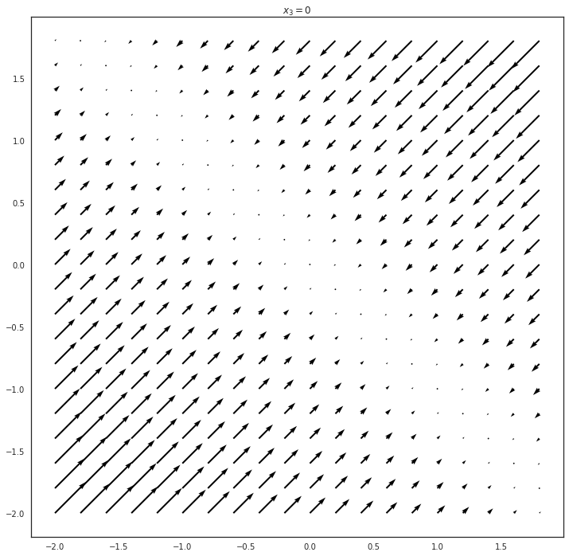

```python
A = np.array([[-0.5, -0.5, 0.], [-0.5, -0.5, 0.],[0.,0.,2.]])
X, Y = np.meshgrid(np.arange(-2, 2 , .2), np.arange(-2, 2, .2))
R=np.tensordot(A[:2,:2], np.stack((X, Y)), axes=[1,0])
f = plt.figure(figsize=(12,12))
ax = f.add_subplot(1,1,1)
ax.set_title(r"$x_3=0$")
Q = ax.quiver(X, Y, R[0], R[1])
```

In the above plot we see the dynamics related to the first two eigen values. One is an attractor the other is marginal stable. The arrows are purely due to the attractor since the marginal stable does not contribute to the dynamics.

[figure not shown]

```python
R=np.tensordot(A[::2,::2], np.stack((X, Y)), axes=[1,0])
f = plt.figure(figsize=(12,12))
ax = f.add_subplot(1,1,1)
ax.set_title(r"$x_2=0$")
Q = ax.quiver(X, Y, R[0], R[1])
```

[figure not shown]

```python
R=np.tensordot(A[1:,1:], np.stack((X, Y)), axes=[1,0])
f = plt.figure(figsize=(12,12))
ax = f.add_subplot(1,1,1)
ax.set_title(r"$x_1=0$")
Q = ax.quiver(X, Y, R[0], R[1])
```

In the above two plot are the dynamics of the unstable and the attractor mixed.

## 1.4 using different basis

[figure not shown]

```python
b=np.array([[1., -1, 0], [0, 0, 1]])
Ab = np.tensordot(A, b, axes=[1,1])
R=np.tensordot(Ab, np.stack((X, Y)), axes=[1,0])
f = plt.figure(figsize=(12,12))
ax = f.add_subplot(1,1,1)
ax.set_title(r"$e_0, e_1$")
Q = ax.quiver(X, Y, R[1], R[2])
```

In the above plot we only consider the dynamics related to the marginal stable and the repellor.

## 1.5 Stationary solution for a constant input

We rewrite the solution of dynamical linear systems given in the lecture:

$\begin{aligned} \mathbf{x}(t) &= e^{t\mathbf{A}}\mathbf{x}_0 + \int_0^Te^{(t-t')\mathbf{A}}\mathbf{u}(t')dt'\\ &= e^{t\mathbf{A}}\mathbf{x}_0 + e^{tA}\int_0^te^{-t'\mathbf{A}}dt'\mathbf{u}\\ &= e^{t\mathbf{A}}\mathbf{x}_0 + e^{tA}\int_0^tP\operatorname{diag}\left(e^{-t'\lambda_1}, \ldots e^{-t' \lambda_m}\right)P^{-1}dt'\mathbf{u}\\ &= e^{t\mathbf{A}}\mathbf{x}_0 + e^{tA}P\operatorname{diag}\left(\int_0^te^{-t'\lambda_1}dt', \ldots \int_0^te^{-t' \lambda_m}dt'\right)P^{-1}\mathbf{u}\\ &= e^{t\mathbf{A}}\mathbf{x}_0 + e^{tA}P\operatorname{diag}\left(\left.-\frac{e^{-t'\lambda_1}}{\lambda_1}\right|_0^t, \ldots, \left.-\frac{e^{-t'\lambda_m}}{\lambda_m}\right|_0^t\right)P^{-1}\mathbf{u}\\ &= e^{t\mathbf{A}}\mathbf{x}_0 + e^{tA}P\operatorname{diag}\left(-\frac{e^{-t\lambda_1}}{\lambda_1}+\frac{1}{\lambda_1}, \ldots,-\frac{e^{-t\lambda_m}}{\lambda_m}+\frac{1}{\lambda_m}\right)P^{-1}\mathbf{u}\\ \end{aligned}$

```python
A = sp.Matrix([[-0.5, -0.5, 0.], [-0.5, -0.5, 0.],[0.,0.,2.]])
P, L = A.diagonalize()
t = sp.Symbol('t')
etL = (t*L).applyfunc(sp.exp)-sp.ones(3)+sp.eye(3)
etA = P.multiply(etL).multiply(P.inv())
```

```python
tp = sp.Symbol("t'")
int_etL = sp.integrate((etL).subs(t, tp), (tp, 0, t))
int_etL
```

$$\left[\begin{matrix}1.0 - 1.0 e^{- 1.0 t} & 0 & 0\\0 & t & 0\\0 & 0 & 0.5 e^{2.0 t} - 0.5\end{matrix}\right]$$

Calculate the solution $\mathbf{x}(t)$

```python
u0, u1, u2 = sp.Symbol("u0"), sp.Symbol("u1"), sp.Symbol("u2")
u = sp.Matrix([u0, u1, u2])
x0, x1, x2 = sp.Symbol("x0"), sp.Symbol("x1"), sp.Symbol("x2")
x = sp.Matrix([x0, x1, x2])
xt = etA.multiply(x) + etA.multiply(P).multiply(int_etL).multiply(P.inv()).multiply(u)
xt
```

$$\left[\begin{matrix}u_{0} \left(0.5 t + 0.5 \left(1.0 - 1.0 e^{- 1.0 t}\right) e^{- 1.0 t}\right) + u_{1} \left(- 0.5 t + 0.5 \left(1.0 - 1.0 e^{- 1.0 t}\right) e^{- 1.0 t}\right) + x_{0} \left(0.5 + 0.5 e^{- 1.0 t}\right) + x_{1} \left(-0.5 + 0.5 e^{- 1.0 t}\right)\\u_{0} \left(- 0.5 t + 0.5 \left(1.0 - 1.0 e^{- 1.0 t}\right) e^{- 1.0 t}\right) + u_{1} \left(0.5 t + 0.5 \left(1.0 - 1.0 e^{- 1.0 t}\right) e^{- 1.0 t}\right) + x_{0} \left(-0.5 + 0.5 e^{- 1.0 t}\right) + x_{1} \left(0.5 + 0.5 e^{- 1.0 t}\right)\\1.0 u_{2} \left(0.5 e^{2.0 t} - 0.5\right) e^{2.0 t} + 1.0 x_{2} e^{2.0 t}\end{matrix}\right]$$

Substitute $\mathbf{s}$ and $\mathbf{x}_0$

```python
xtSubs = xt.subs({x0: 0, x1: 0, x2: 0}).subs({u0: 1, u1: 2., u2: 0})
xtSubs
```

$$\left[\begin{matrix}- 0.5 t + 1.5 \left(1.0 - 1.0 e^{- 1.0 t}\right) e^{- 1.0 t}\\0.5 t + 1.5 \left(1.0 - 1.0 e^{- 1.0 t}\right) e^{- 1.0 t}\\0\end{matrix}\right]$$

Calculating the limit for $t \rightarrow \infty$

```python
sp.limit(xtSubs[0], t, sp.oo)
```

$$-\infty$$

```python
sp.limit(xtSubs[1], t, sp.oo)
```

$$\infty$$

```python
sp.limit(xtSubs[2], t, sp.oo)
```

$$0$$

Quiver plots

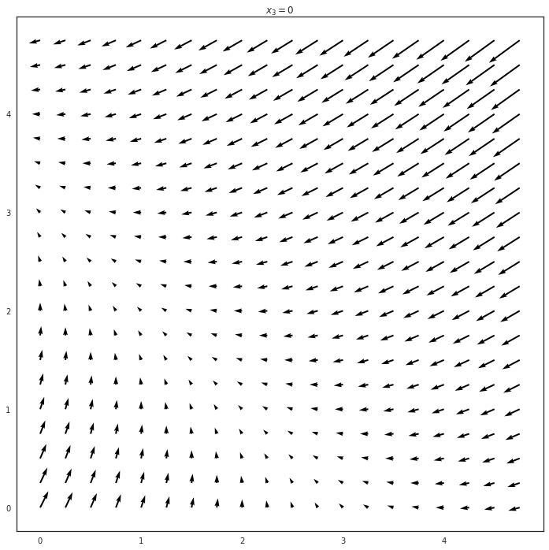

```python
A = np.array([[-0.5, -0.5, 0.], [-0.5, -0.5, 0.],[0.,0.,2.]])
X, Y = np.meshgrid(np.arange(0, 5 , .25), np.arange(0, 5, .25))
R=np.tensordot(A[:2,:2], np.stack((X, Y)), axes=[1,0])
f = plt.figure(figsize=(12,12))
ax = f.add_subplot(1,1,1)
ax.set_title(r"$x_3=0$")
Q = ax.quiver(X, Y, R[0]+1, R[1]+2)
```

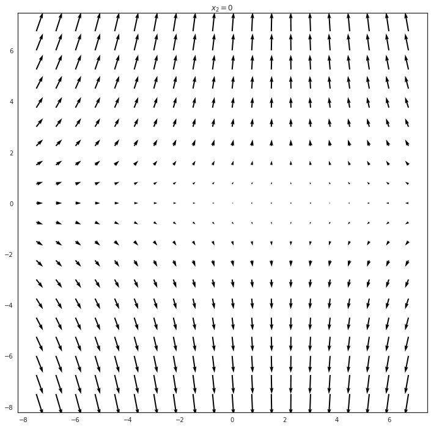

```python
A = np.array([[-0.5, -0.5, 0.], [-0.5, -0.5, 0.],[0.,0.,2.]])
X, Y = np.meshgrid(np.arange(-7.5, 7.5 , .75), np.arange(-7.5, 7.5, .75))
R=np.tensordot(A[::2,::2], np.stack((X, Y)), axes=[1,0])
f = plt.figure(figsize=(12,12))
ax = f.add_subplot(1,1,1)
ax.set_title(r"$x_2=0$")
Q = ax.quiver(X, Y, R[0]+1, R[1])
```

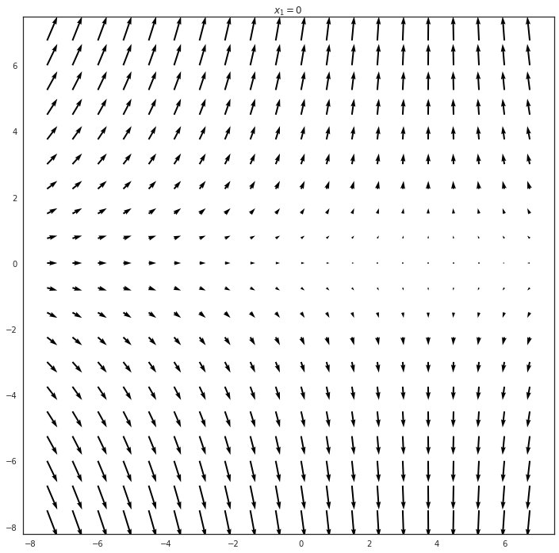

```python
A = np.array([[-0.5, -0.5, 0.], [-0.5, -0.5, 0.],[0.,0.,2.]])
X, Y = np.meshgrid(np.arange(-7.5, 7.5 , .75), np.arange(-7.5, 7.5, .75))
R=np.tensordot(A[1:,1:], np.stack((X, Y)), axes=[1,0])
f = plt.figure(figsize=(12,12))
ax = f.add_subplot(1,1,1)
ax.set_title(r"$x_1=0$")
Q = ax.quiver(X, Y, R[0]+2, R[1])
```

```python
u = np.array([1,2,0])
np.tensordot(u, b, axes=[0,1])
```

```
array([-1.,  0.])
```

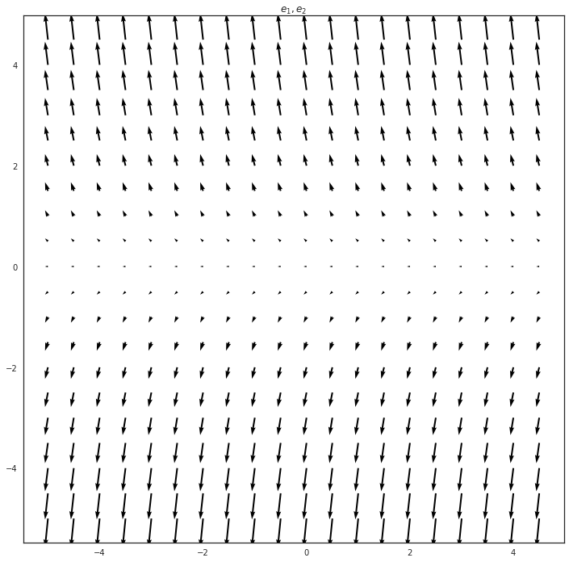

```python
A = np.array([[-0.5, -0.5, 0.], [-0.5, -0.5, 0.],[0.,0.,2.]])
X, Y = np.meshgrid(np.arange(-5, 5 , .5), np.arange(-5, 5, .5))
b=np.array([[1., -1, 0], [0, 0, 1]])
Ab = np.tensordot(A, b, axes=[1,1])
R=np.tensordot(Ab, np.stack((X, Y)), axes=[1,0])
f = plt.figure(figsize=(12,12))
ax = f.add_subplot(1,1,1)
ax.set_title(r"$e_1, e_2$")
Q = ax.quiver(X, Y, R[1]-1, R[2])
```